# Lecture 10: Functional decomposition

Munir Hiabu

## Local and Global Explanations

- In this lecture we will connect the concept of local and global explanations via functional decompositions

## Partial dependence plots Toy example I

https://detralytics.com/wp-content/uploads/2020/03/Faqctuary_2020-02_Features-with-flat-partial-dependence-plots.pdf

- $X_1=$ Gender: policyholder’s gender (female or male);
- $X_2=$ Age: policyholder’s age (integer values from 18 to 65 );
- $X_3=$ Split: whether the policyholder splits its annual premium or not (yes or no);
- $X_4=$ Sport: whether the policyholder’s car is a sports car or not (yes or no).

$\begin{aligned} \lambda(\boldsymbol{x})= & 0.3 \times\left(1+0.1 I_{\left\{{\color{#5692e4}x_1}=\text { male }\right\}}\right) \\ & \times\left(1+\frac{1}{\sqrt{{\color{#D9421A}x_2}-17}}\right) \\ & \times\left(1+0.3 I_{\left\{18 \leq {\color{#D9421A}x_2}<35\right\}I_{\left\{{\color{#009151}x_4}=\text { yes }\right\}}}-0.3 I_{\left\{45 \leq {\color{#D9421A}x_2}<65\right\}I_{\left\{{\color{#009151}x_4}=\text { yes }\right\}}}\right) \end{aligned}$

## Partial dependence plots Toy example I

### Random forest explanations

- Problem in Toy Example: partial dependence plots indicate that $X_4$ (sports car) has no effect. This is happening because $X_4$ only has an effect via an interaction with $X_2$ (age).

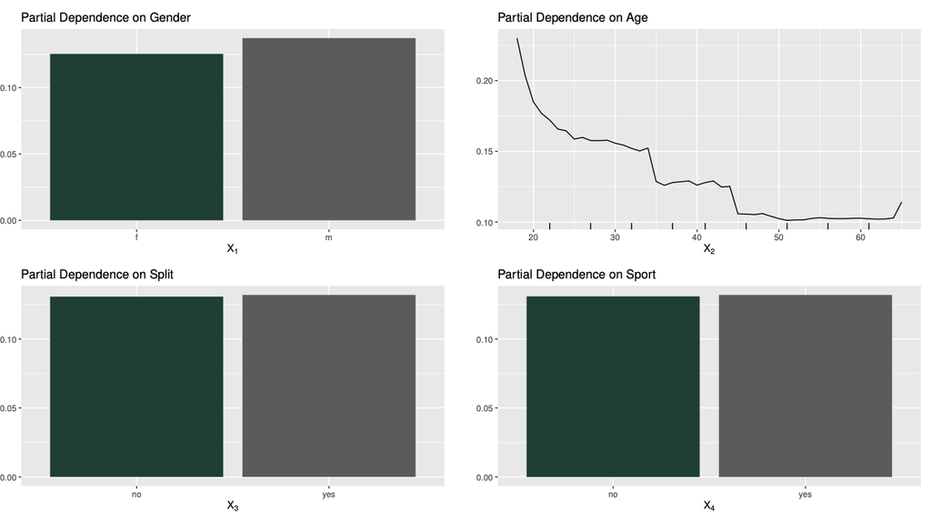

## Shapley values Toy example II

**Toy example II**

$$\hat m_n(x_1,x_2)=x_1+x_2 + 2x_1x_2.$$

The interventional SHAP value for the first feature is
$$\phi_1(x_1,x_2)=x_1-\mathbb E[X_1]+x_1x_2 -\mathbb E[X_1X_2]+x_1\mathbb E[X_2]-x_2\mathbb E[X_1].$$
If the features are standardized, i.e., $X_1$ and $X_2$ have mean zero and variance one, then

$$\phi_1(x_1,x_2)=x_1+x_1x_2 -\textrm{corr}(X_1,X_2).$$

- Assume $\textrm{corr}(X_1,X_2)=0.3$
  - individual with $x_1=1$ and $x_2=-0.7$ would see a SHAP value of 0 for the first feature:
    $$\phi_1(1,-0.7) = 0.$$

## Conclusion of example I+II

- Partial dependence plots seem to ignore interaction effects
- Interventional SHAP values merge interaction effects and main effect and can thereby cancel each other out
- Conclusion: Both SHAP values and partial dependence plots have problems with interactions…

Functional decompositions

## Functional decompositions

Assume a data set with $p$ features. Also assume that we can approximate the regression function $m$ by a (q-th) order functional decomposition:

$$m(x) \approx m_0+\sum_{k=1}^p m_k(x_{k}) + \sum_{k_1<k_2} m_{k_1k_2}(x_{k_1},x_{k_2}) + \cdots +\sum_{k_1<\cdots <k_q} m_{k_1,\dots,k_q} (x_{k_1},\dots,x_{k_q}).$$

- conjectured optimal rates of convergence under the assumption that $m$ has two continuous partial derivatives:

| Model general | \(p= 6\) | Comparable sample sizes for \(p= 6\) |
| --- | --- | --- |
| Full model | \(O_p(n^{-2/(p+4)})\) = \(O_p(n^{-1/5})\) | 1 000 000 |
| Interaction (q) | \(O_p(n^{-2/(q+4)})\) | 1 000 -- 1 000 000 |
| Interaction (q=2) | \(O_p(n^{-1/3})\) | 4 000 |
| Additive (q=1) | \(O_p(n^{-2/5})\) | 1 000 |

## Functional decompositions Generalized ANOVA

Generalized ANOVA is probably the most considered functional decomposition identification Stone (1994). We consider $\mathcal X=\mathbb R^{p}$ (such that the number of covariates is no being confused with the density).

- **Generalized ANOVA**: For every $S\subseteq \{1,\dots,p\}$
  and $k\in S$,
  $$\int m_{S}\left(x_{S}\right) \int w(x) \mathrm dx_{-S} \ \mathrm d x_{k}=0$$

Common choices for $w$ are

- $w \equiv 1$
- $w(x)=p(x),\$ $p(x)=$ density of $X$.
- $w(x)=\prod p_j(x_j),\$ $p_j(x_j)=$ density of $X_j.$
- Generalized ANOVA, however, has drawbacks for interpretability
  - $w=1$ ignores the distribution of $X$
  - $w(x)=p(x)$ uses the correlation structure (analog to observational SHAP)
  - $w(x)=\prod p_j(x_j)$ Assumes that features are independent

Marginal Identification

## Functional decompositions Marginal Identification

**Definition [Marginal identification]**

Consider a regression function $m: \mathbb R^p \rightarrow \mathbb R$ with functional decomposition
$$m(x)=\sum_{S\subseteq I_p} m_S$$
If for every $S\subseteq I_p$,
$$\sum_{T: T \cap S \neq \emptyset} \int m_T(x_T) p_{S}(x_{S}) \mathrm dx_S=0,$$
we say that the functional decomposition satifies the marginal identification.

**Theorem (Existence and uniqueness of marginal identification)**

Given a function $m$, there exists exactly one set of components $\{m_S| S \subseteq I_p\}$ that fulfill the marginal identification. They are given as
$$m_S (x_S)= \sum_{V\subset S} (-1)^{|S\setminus V|}\xi_S(x_S),$$
where $\xi_S$ doentes the partial dependence plot of a set $S$. In particular, and $\xi_\emptyset=\mathbb E[m(X)]$.

## A functional decomposition Marginal Identification

**Corollary [Marginal identification $\leftrightarrow$ PDP ]**

If $\hat m_n=\sum_S \hat m_S$ satisfies the marginal identification, then
$$\xi_S=\sum_{U \subseteq S} \hat m_U.$$
In particular if $S$ is only one feature, i.e., $S=\{k\}$, we have
$$\xi_k(x_k)= \hat m_0 + \hat m_k(x_k).$$

## Functional decompositions Marginal Identification: Interventional SHAP values

**Theorem [Marginal identification $\leftrightarrow$ Interventional SHAP ]**

If $\hat m_n=\sum_S \hat m_S$ satisfies the marginal identification, then

- Interventional SHAP values are weighted averages of the components
  - interaction component is equally split between involved features:

$$\phi_k(x)= \hat m_k(x_k)+ \frac 1 2 \sum_j \hat m_{kj}(x_{kj}) + \cdots + \frac 1 p \hat m_{1,\dots,p}(x_{1,\dots,p}).$$

## Functional decompositions Partial Dependence Plot: Toy example I (revisited)

We now fit and interpret the data via a functional decomposition with marginal identification.

```r
library(xgboost)
library(glex)
xg <- xgboost(data = cbind(x1,x2,x3,x4), label = y, params = list(max_depth = 4, eta = .01, objective = "count:poisson"), nrounds = 100,verbose = 0)
res <- glex(xg, x) #### calculates functional decomposition with marginal identification
res$m
```

```
                 x1           x2           x4         x1:x2        x1:x4
              <num>        <num>        <num>         <num>        <num>
     1: -0.01153930  0.254763806 -0.003807825  0.0115393039  0.001131369
     2: -0.01153930 -0.070856660  0.003796980 -0.0030981568 -0.001124274
     3: -0.01153930 -0.073284602  0.003796980 -0.0006702144 -0.001124274
     4: -0.01153930 -0.009837431  0.003796980 -0.0020662462 -0.001124274
     5:  0.01153167 -0.069309124  0.003796980  0.0015543309  0.001129098
    ---
499996:  0.01153167 -0.009837431  0.003796980  0.0020742189  0.001129098
499997: -0.01153930  0.064109258 -0.003807825  0.0022360787  0.001131369
499998: -0.01153930  0.075669850 -0.003807825  0.0022360787  0.001131369
499999: -0.01153930 -0.075727647  0.003796980 -0.0031179563 -0.001124274
500000:  0.01153167 -0.075727647 -0.003807825  0.0031216284 -0.001129654
               x2:x4      x1:x2:x4
               <num>         <num>
     1:  0.067772348 -1.131369e-03
     2:  0.052166467 -2.518432e-03
     3:  0.049741495 -9.346023e-05
     4: -0.005752768 -4.512167e-04
     5:  0.053718925  9.701917e-04
    ---
499996: -0.005752768  4.503037e-04
499997:  0.051318240 -2.826504e-03
499998:  0.062867555 -2.826504e-03
499999:  0.047290680 -2.538208e-03
500000: -0.047238057 -2.530277e-03
```

## Functional decompositions Partial Dependence Plot: Toy example I (revisited)

```r
library(glex)
# Model fitting
library(xgboost)
# Visualization
library(ggplot2)
library(patchwork)
theme_set(theme_minimal(base_size = 13))
vi_xgb <- glex_vi(res)

p_vi <- autoplot(vi_xgb, threshold = 0) +
  labs(title = NULL, tag = "XGBoost-explanation")

p_vi+
  plot_annotation(title = "Variable importance scores by term") &
  theme(plot.tag.position = "bottomleft")
```

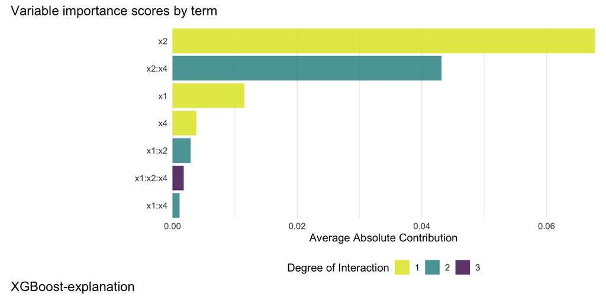

## Functional decompositions Partial Dependence Plot: Toy example I (revisited)

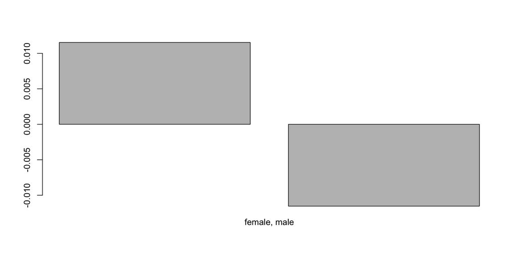

```r
#| code-fold: true
barplot(as.numeric(c(res$m$x1[which.min(x1==0)], res$m$x1[which.min(x1==1)])), names.arg=("female, male") )
```

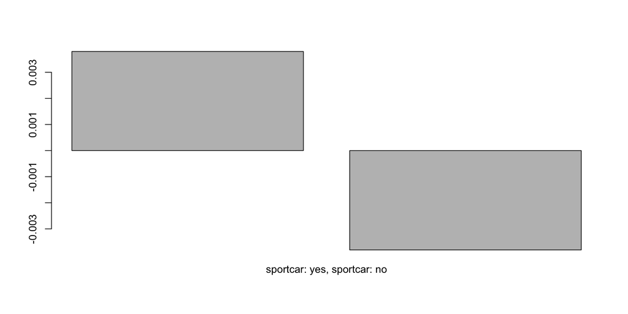

```r
barplot(as.numeric(c(res$m$x4[which.min(x4==1)], res$m$x4[which.min(x4==0)])), names.arg=("sportcar: yes, sportcar: no") )
```

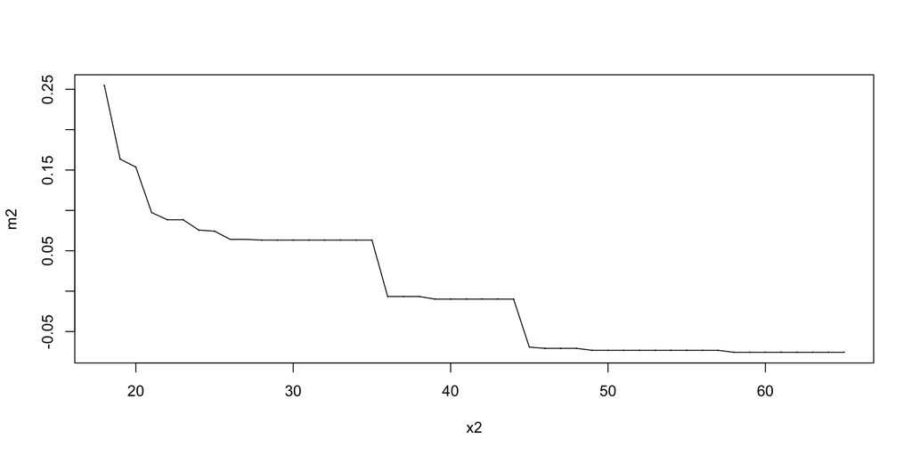

```r
plot(as.numeric(x2[order(x2)]), as.numeric(res$m$x2[order(x2)]),type="l", xlab="x2", ylab="m2")
```

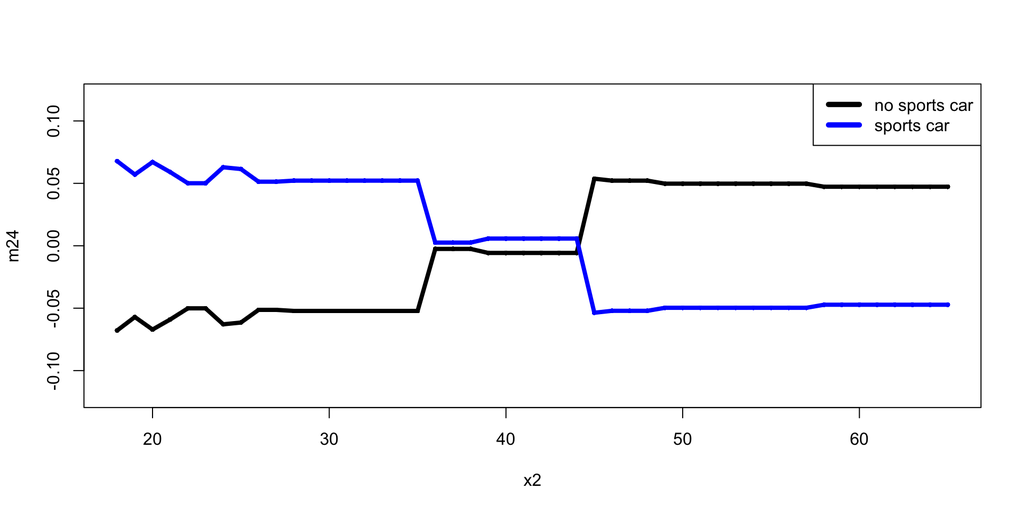

```r
plot(as.numeric(x2[which(x4==0)][order(x2[which(x4==0)])]),as.numeric(res$m$`x2:x4`[which(x4==0)][order(x2[which(x4==0)])]), type="l" ,ylim=c(-0.12,0.12), lwd=4, xlab="x2", ylab="m24")
lines(as.numeric(x2[which(x4==1)][order(x2[which(x4==1)])]),as.numeric(res$m$`x2:x4`[which(x4==1)][order(x2[which(x4==1)])]), type="l", col="blue", lwd=4)
legend("topright", legend=c("no sports car", "sports car"),
       col=c("black", "blue"), cex=1, lwd=5)
```

## Functional decompositions Interventional SHAP: Toy example II (revisited)

Stone, Charles J. 1994. “The Use of Polynomial Splines and Their Tensor Products in Multivariate Function Estimation.” *The Annals of Statistics* 22 (1): 118–71.